# Machine Learning in R

Author

Sebastian Fischer

## `mlr3` Recap

Before diving into `mlr3torch`, we will briefly review the core building blocks of the `mlr3` machine learning framework. For reference, we recommend the [mlr3 book](https://mlr3book.mlr-org.com/) that explains the `mlr3` framework in more detail. Additionally, the [mlr3 website](https://mlr-org.com/) contains more tutorials and overviews.

### Task

A task is a machine learning problem on a dataset. It consists of the data itself and some metadata such as the features or the target variable. To create an example task that comes with `mlr3`, we can use the `tsk()` function:

```r
library(mlr3)
set.seed(42)
tsk("iris")
```

```
── <TaskClassif> (150x5): Iris Flowers ─────────────────────────────────────────
• Target: Species
• Target classes: setosa (33%), versicolor (33%), virginica (33%)
• Properties: multiclass
• Features (4):
```

To create a custom `Task` from a `data.frame`, we can use the `as_task_<type>` converters:

```r
head(iris)
```

```
  Sepal.Length Sepal.Width Petal.Length Petal.Width Species
1          5.1         3.5          1.4         0.2  setosa
2          4.9         3.0          1.4         0.2  setosa
3          4.7         3.2          1.3         0.2  setosa
4          4.6         3.1          1.5         0.2  setosa
5          5.0         3.6          1.4         0.2  setosa
6          5.4         3.9          1.7         0.4  setosa
```

```r
tsk_iris <- as_task_classif(iris, id = "iris", target = "Species")
tsk_iris
```

```
── <TaskClassif> (150x5) ───────────────────────────────────────────────────────
• Target: Species
• Target classes: setosa (33%), versicolor (33%), virginica (33%)
• Properties: multiclass
• Features (4):
```

**Tip**

To get the help page for an `mlr3` object, you can call `tsk_iris$help()`.

You can access the data of a task using the `$data()` method, which accepts arguments `rows` and `cols` to select specific rows and columns.

```r
tsk_iris$data(rows = 1:5, cols = c("Sepal.Length", "Sepal.Width"))
```

```
   Sepal.Length Sepal.Width
          <num>       <num>
1:          5.1         3.5
2:          4.9         3.0
3:          4.7         3.2
4:          4.6         3.1
5:          5.0         3.6
```

Using the `mlr3viz` extension, we can get an overview of the target distribution:

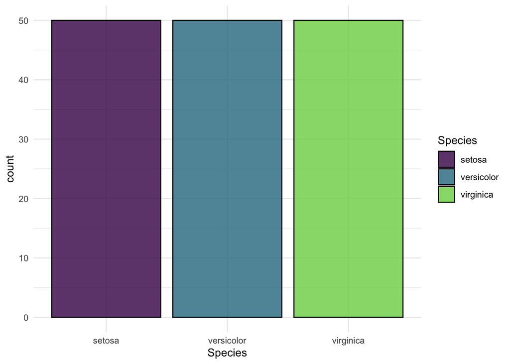

```r
library(mlr3viz)
autoplot(tsk_iris)
```

### Learner

A learner is a machine learning algorithm that can be `$train()`ed on a `Task` and be used to make `$predict()`ions on it. An overview of all learners is shown on our [website](https://mlr-org.com/learners.html). We can construct one by passing the identifier of the learner to the `lrn()` function.

```r
lrn_tree <- lrn("classif.rpart")
lrn_tree
```

```
── <LearnerClassifRpart> (classif.rpart): Classification Tree ──────────────────
• Model: -
• Parameters: xval=0
• Packages: mlr3 and rpart
• Predict Types: [response] and prob
• Feature Types: logical, integer, numeric, factor, and ordered
• Encapsulation: none (fallback: -)
• Properties: importance, missings, multiclass, selected_features, twoclass,
and weights
• Other settings: use_weights = 'use'
```

Next, we need to split the data into a training and test set and apply the learner on the former.

```r
split <- partition(tsk_iris, ratio = 0.8)
lrn_tree$train(tsk_iris, row_ids = split$train)
```

The trained model can be accessed via the `$model` slot of the learner:

```r
print(lrn_tree$model)
```

```
n= 120

node), split, n, loss, yval, (yprob)
      * denotes terminal node

1) root 120 79 setosa (0.34166667 0.32500000 0.33333333)
  2) Petal.Length< 2.45 41  0 setosa (1.00000000 0.00000000 0.00000000) *
  3) Petal.Length>=2.45 79 39 virginica (0.00000000 0.49367089 0.50632911)
    6) Petal.Width< 1.65 41  3 versicolor (0.00000000 0.92682927 0.07317073) *
    7) Petal.Width>=1.65 38  1 virginica (0.00000000 0.02631579 0.97368421) *
```

To make predictions on the test set, we can use the `$predict()` method of the learner:

```r
predictions <- lrn_tree$predict(tsk_iris, row_ids = split$test)
```

To make predictions on `data.frame`s, we can use the `$predict_newdata()` method of the learner:

```r
new_data <- iris[1:2, ]
lrn_tree$predict_newdata(new_data)
```

```
── <PredictionClassif> for 2 observations: ─────────────────────────────────────
 row_ids  truth response
       1 setosa   setosa
       2 setosa   setosa
```

### Performance Evaluation

To assess the quality of the predictions, we can use a `Measure`. `mlr3` comes with many predefined measures, and we can construct them by passing the name of the measure to the `msr()` function. Below, we construct the mean classification accuracy measure – which can only be applied to classification tasks – and use it to evaluate the predictions.

```r
acc <- msr("classif.acc")
predictions$score(acc)
```

```
classif.acc
  0.9333333
```

For more elaborate evaluation strategies, we can use `rsmp()` to define a `Resampling` strategy that can be executed using `resample()`.

```r
rsmp_cv <- rsmp("cv", folds = 3)

rr <- resample(
  task       = tsk_iris,
  learner    = lrn_tree,
  resampling = rsmp_cv
)
rr
```

```
── <ResampleResult> with 3 resampling iterations ───────────────────────────────
 task_id    learner_id resampling_id iteration     prediction_test warnings
    iris classif.rpart            cv         1 <PredictionClassif>        0
    iris classif.rpart            cv         2 <PredictionClassif>        0
    iris classif.rpart            cv         3 <PredictionClassif>        0
 errors
      0
      0
      0
```

```r
rr$score(acc)
```

```
   task_id    learner_id resampling_id iteration classif.acc
    <char>        <char>        <char>     <int>       <num>
1:    iris classif.rpart            cv         1        0.96
2:    iris classif.rpart            cv         2        0.96
3:    iris classif.rpart            cv         3        0.92
Hidden columns: task, learner, resampling, prediction_test
```

```r
rr$aggregate(acc)
```

```
classif.acc
  0.9466667
```

### Hyperparameter Tuning

Hyperparameter tuning is an essential process in machine learning to optimize the performance of models by selecting the best combination of hyperparameters. In the `mlr3` framework, hyperparameter tuning is facilitated by the [`mlr3tuning`](https://github.com/mlr-org/mlr3tuning) extension.

We will now demonstrate how to tune the hyperparameters of the `classif.rpart` learner.

1. **Define the Search Space**: Specify the range and distribution of hyperparameters to explore.

   ```r
   library(mlr3tuning)
   lrn_tree$configure(
     cp = to_tune(lower = 0.001, upper = 0.1),
     maxdepth = to_tune(lower = 1, upper = 30)
   )
   ```

2. **Choose a Resampling Strategy**: Determine how to evaluate each hyperparameter configuration’s performance.

   ```r
   rsmp_tune <- rsmp("cv", folds = 3)
   ```

3. **Select a Tuner**: Decide on the algorithm that will search through the hyperparameter space.

   ```r
   tuner <- tnr("random_search")
   ```

4. **Select a Measure**: Define the metric to optimize during tuning.

   ```r
   msr_tune <- msr("classif.acc")
   ```

5. **Execute Tuning**: Run the tuning process to find the optimal hyperparameters. Here we also specify our budget of 10 evaluations.

   ```r
   tune_result <- tune(
     task = tsk_iris,
     learner = lrn_tree,
     resampling = rsmp_tune,
     measure = msr_tune,
     tuner = tuner,
     term_evals = 10L
   )
   ```

6. **Apply the Best Hyperparameters**: Update the learner with the best-found hyperparameters and retrain the model.

   ```r
   lrn_tree$param_set$values <- tune_result$result_learner_param_vals
   lrn_tree$train(tsk_iris)
   ```

These two steps can also be encapsulated in the `AutoTuner` class, which first finds the best hyperparameters and then trains the model with them.

```r
at <- auto_tuner(
  learner = lrn_tree,
  resampling = rsmp_tune,
  measure = msr_tune,
  term_evals = 10L,
  tuner = tuner
)
```

The `AutoTuner` can be used just like any other `Learner`. To get a valid performance estimate of the tuning process, we can `resample()` it on the task. This is called *nested resampling*: the outer resampling is for evaluation and the inner resampling is for tuning.

```r
rr <- resample(tsk_iris, at, rsmp_tune)
rr$aggregate(acc)
```

```
classif.acc
  0.9466667
```

### Learning Pipelines

In many cases, we don’t only fit a single learner but a whole learning pipeline. Common use cases include the preprocessing of the data, e.g., for imputing missing values, scaling the data, or encoding categorical features, but many other operations are possible. The `mlr3` extension [`mlr3pipelines`](https://mlr3pipelines.mlr-org.com/) is a toolbox for defining such learning pipelines. Its core building block is the `PipeOp` that can be constructed using the `po()` function.

```r
library(mlr3pipelines)
pca <- po("pca")
```

Just like a learner, it has a `$train()` and `$predict()` method, and we can apply it to a `Task` using these methods.

```r
pca$train(list(tsk_iris))
```

```
$output

── <TaskClassif> (150x5) ───────────────────────────────────────────────────────
• Target: Species
• Target classes: setosa (33%), versicolor (33%), virginica (33%)
• Properties: multiclass
• Features (4):
```

```r
pca$predict(list(tsk_iris))[[1L]]
```

```
── <TaskClassif> (150x5) ───────────────────────────────────────────────────────
• Target: Species
• Target classes: setosa (33%), versicolor (33%), virginica (33%)
• Properties: multiclass
• Features (4):
```

Usually, such `PipeOp`s are combined with a `Learner` into a full learning `Graph`. This is possible using the `%>>%` chain operator.

```r
library(mlr3pipelines)
graph <- po("pca") %>>% lrn("classif.rpart")
print(graph)
```

```
Graph with 2 PipeOps:
            ID         State      sccssors prdcssors
        <char>        <char>        <char>    <char>
           pca <<UNTRAINED>> classif.rpart
 classif.rpart <<UNTRAINED>>                     pca
```

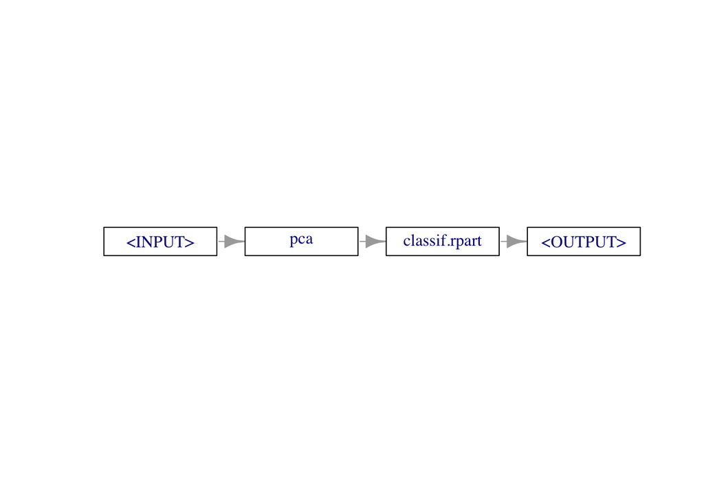

```r
graph$plot(horizontal = TRUE)
```

The resulting `Graph` can be converted back into a `Learner` using the `as_learner()` function and used just like any other `Learner`.

```r
glrn <- as_learner(graph)
glrn$train(tsk_iris)
```

### Parallelization

In order to speed up computations in `mlr3`, there are various approaches:

1. Use a `Learner`’s internal parallelization capapabilities, which is independent from `mlr3` and which can be set via the `set_threads()` function.
2. Use `future` to parallelize the execution of a resampling or a benchmark.
3. Soon it will be possible to use `mirai` as a plug-in replacement for `future`, which is significantly faster and easier to configure.
4. Use `mlr3batchmark` for parallelization on HPC clusters.

You can read [Chapter 10](https://mlr3book.mlr-org.com/chapters/chapter10/advanced_technical_aspects_of_mlr3.html#sec-parallelization) and [Chapter 11](https://mlr3book.mlr-org.com/chapters/chapter11/large-scale_benchmarking.html#sec-hpc-exec) of the `mlr3` book on that. Here, we will briefly demonstrate how to parallelize a resampling using `future`.

In the simplest scenario (no nested parallelization), we only need to call a single functions from future and specify the number of workers:

```r
future::plan("multisession", workers = 5)
rr = resample(tsk_iris, lrn_tree, rsmp("cv", folds = 10))
```